# quiz 3

박찬영

2024-11-20

load required packages

```r
library(mosaicData)
library(tidyverse)
library(stringr)
library(lubridate)
library(forcats)
```

```r
wd <- paste0(getwd(), "\\R\\2024\\quiz 3\\")
bike_day <- read_csv(paste0(wd, "bike_day.csv"))
bike_hour <- read_csv(paste0(wd, "bike_hour.csv"))
books <- read_csv(paste0(wd, "books.csv"))
```

## Problem 1. [16점]

`mosaicData` 패키지의 `Gestation` 데이터에는 아이의 출산 기간과 부모에 대한 정보가 포함되어 있으며, 아이의 부모에 대한 정보도 기록되어 있다.

문제에서 사용할 변수에 대한 설명은 다음과 같다.

- `ed`, `ded`: `<chr>` 각각 아이의 엄마, 아빠의 학력
- `inc`: `<chr>` 가족 연단위 수입. $2500 단위로 구분 (`"0-2500"`, `"2500-5000"`, …, `"17500-20000"`, `"20000-22500"`, `"15000+"`)
- `gestation`: `<dbl>` 임신 기간 (일수 기준)
- `smoke`: `<chr>` 산모의 흡연 여부
- `number`: `<chr>` 산모의 하루 흡연량
- `age`: `<dbl>` 출산 당시 산모의 나이

### (a) `mosaicData::Gestation`의 `ed`, `ded` 변수를 factor 형식으로 바꾸고, level을 다음과 같이 통합하시오.

### 변경한 데이터셋을 `Ges`라는 이름으로 저장하시오. (3점)

- `"College graduate"` ← `"College graduate"`을 그대로 이용
- `"Highschool graduate"` ← `"HS graduate--no other schooling"`, `"HS+some college"`, `"HS+trade"`을 통합
- `"Others"` ← `"8th -12th grade - did not graduate"`, `"Trade school HS unclear"`, `"less than 8th grade"`을 통합

```r
ned <- fct_collapse(
  parse_factor(Gestation$ed),
  "College graduate" = "College graduate",
  "Highschool graduate" = c("HS graduate--no other schooling",
    "HS+some college",
    "HS+trade"
  ),
  Others = c("8th -12th grade - did not graduate",
    "Trade school HS unclear",
    "less than 8th grade"
  )
)

nded <- fct_collapse(
  parse_factor(Gestation$ded),
  "College graduate" = "College graduate",
  "Highschool graduate" = c("HS graduate--no other schooling",
    "HS+some college",
    "HS+trade"
  ),
  Others = c("8th -12th grade - did not graduate",
    "Trade school HS unclear",
    "less than 8th grade"
  )
)

Ges <- Gestation %>%
  mutate(ed = ned, ded = nded)
```

### (b) `Ges` 데이터셋에 있는 `inc` 변수의 값은 다음과 같다.

### `inc` 변수의 형식을 다음과 같이 변경하고, 저장하시오. (4점)

- `"0-2500"`, `"2500-5000"`, …, `"20000-22500"` → `"$ 0 to 2500"`, `"$ 2500 to 5000"`, …, `"$ 20000 to 22500"`
- `"15000+"`은 `"$ 15000 over"`이 아닌 `"$ 25000 over"`으로 변경한다.

```r
Ges$inc <- Ges$inc %>%
  fct_recode(
    "$ 0 to 2500" = "0-2500",
    "$ 2500 to 5000" = "2500-5000",
    "$ 5000 to 7500" = "5000-7500",
    "$ 7500 to 10000" = "7500-10000",
    "$ 10000 to 12500" = "10000-12500",
    "$ 12500 to 15000" = "12500-15000",
    "$ 15000 to 17500" = "15000-17500",
    "$ 17500 to 20000" = "17500-20000",
    "$ 20000 to 22500" = "20000-22500",
    "$ 25000 over" = "15000+"
  )
```

### (c) Ges 데이터셋의 number와 gestation의 관계를 시각화하고자 한다.

- 현재 산모가 흡연 중이고(`smoke == "now"`), `gestation`, `number`가 NA가 아닌 관찰값만을 이용한다.
- `number` 변수를 `factor`로 변환한다. level의 순서는, 일일 흡연량을 기준으로 오름차순으로 정렬한다.

### 위의 과정을 거쳐, 아래와 같은 boxplot을 출력하시오. (4점)

- single pipeline으로 작성하시오.

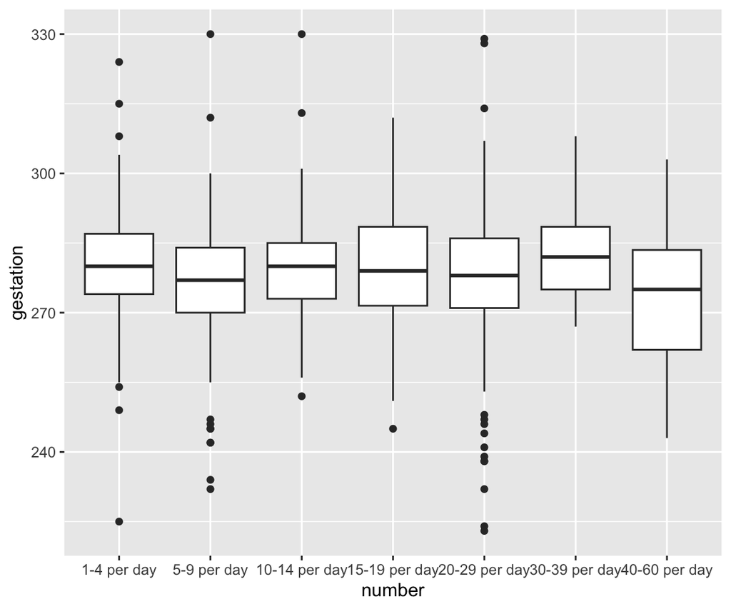

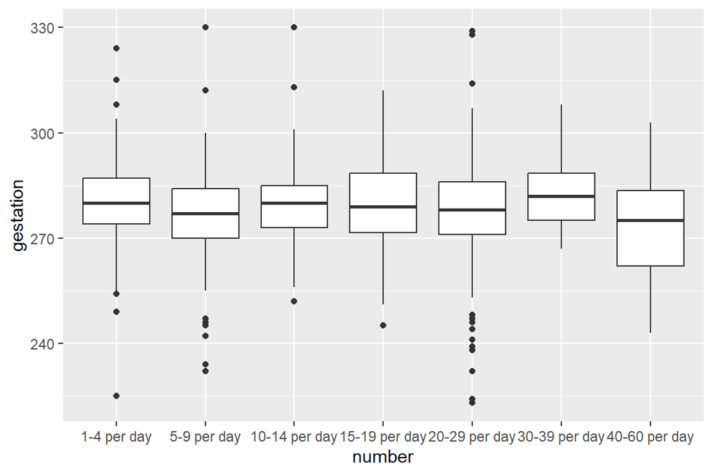

```r
Ges %>%
  filter(!is.na(gestation), !is.na(number), smoke == "now") %>%
  mutate(number = parse_factor(number)) %>%
  mutate(number = fct_relevel(
    number,
    c("1-4 per day",
      "5-9 per day", "10-14 per day",
      "15-19 per day", "20-29 per day",
      "30-39 per day", "40-60 per day"
    )
  )) %>%
  ggplot(aes(x = number, y = gestation)) +
  geom_boxplot()
```

### (d) `Ges` 데이터셋의 `inc`와 `age`의 관계를 보고자 한다.

- `age`와 `inc`가 `NA`가 아닌 관찰값만 사용한다.
- `inc` 변수를 `factor`로 변환한다. level의 순서는, level별 `age`의 평균을 기준으로 오름차순으로 정렬한다.
- `age`를 x축으로 하는 히스토그램을 그리고, `inc`별로 `facet`을 나누어 비교한다. `bin`의 개수는 자유롭게 정한다.

### 위의 과정을 거쳐, 아래와 같은 histogram을 출력하고 `inc`와 `age`의 관계에 대한 해석을 서술하시오. (5점)

- single pipeline으로 작성하시오.

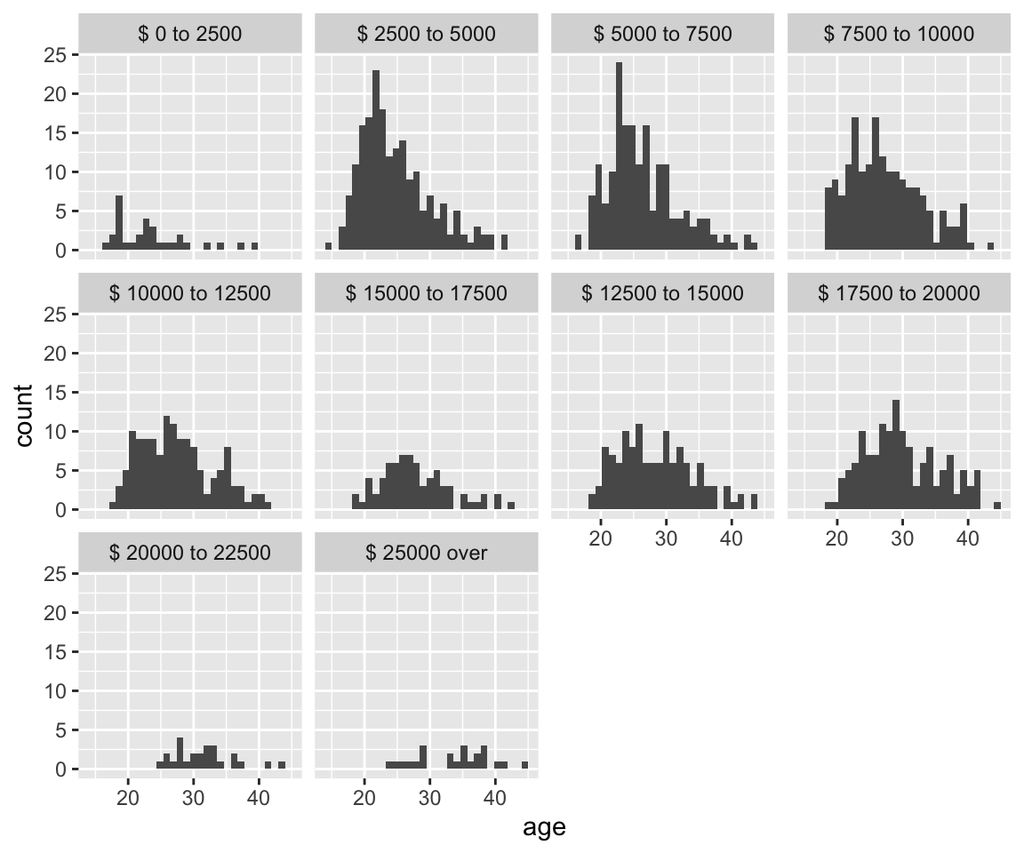

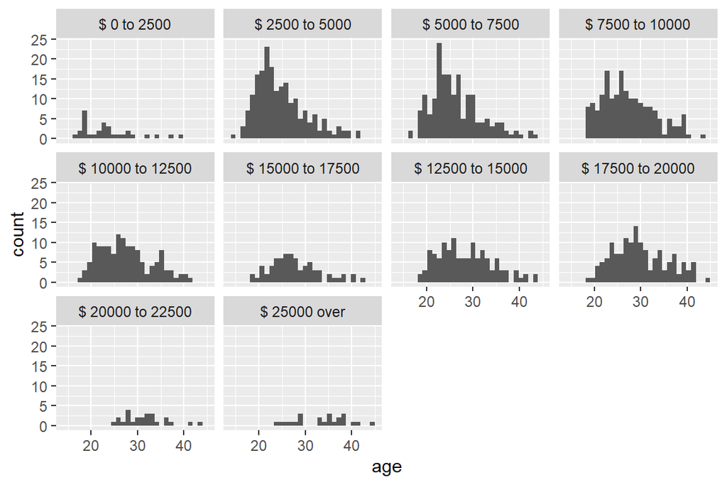

```r
Ges %>%
  filter(!is.na(inc), !is.na(age)) %>%
  group_by(inc) %>%
  mutate(avage = mean(age)) %>%
  ungroup() %>%
  mutate(inc = fct_reorder(inc, avage)) %>%
  ggplot(aes(age)) +
  geom_histogram(bins = 30) +
  facet_wrap(~inc, nrow = 3)
```

$20000 이하의 소득에서는 모두 20대의 수가 많은 것을 볼 수 있다. 그러나 $20000 이상의 소득에는 20대가 많이 없는 것을 확인 할 수 있다.

## Problem 2. [18점]

`bike_day.csv`, `bike_hour.csv`는 날짜/시간별 자전거 대여시스템 이용에 관한 데이터이다.

변수에 대한 설명은 다음과 같다.

- `bike_day$dteday`: `<date>` `2011-01-01` ~ `2012-12-31` 까지의 날짜
- `bike_hour$date`: `<chr>` `"3/1 (2011)"` ~ `"9/30 (2011)"` 까지의 날짜
- `bike_hour$hour`: `<chr>` `"12 AM"`, `"1 AM"`, …, `"11 PM"` 형태의 시간
- `bike_hour$total`: `<dbl>` 해당 `date`, `hour`의 총 자전거 대여 횟수.

### (a) `bike_day.csv`, `bike_hour.csv`을 각각 `bike_day`, `bike_hour`라는 이름의 tibble로 저장하시오. (3점)

```r
bike_day <- read_csv(paste0(wd, "bike_day.csv"))
bike_hour <- read_csv(paste0(wd, "bike_hour.csv"))
```

### (b) `bike_hour` 데이터셋의 `date`의 형식을 character에서 date으로 변경하고, 저장하시오.

### 저장 후 상위 10개 행을 출력하시오. (3점)

```r
bike_hour$date <- bike_hour$date %>%
  parse_date(format = "%m/%d (%Y)")

bike_hour %>% head(10)
```

```
## # A tibble: 10 × 3
##    date       hour  total
##    <date>     <chr> <dbl>
##  1 2011-03-01 12 AM     7
##  2 2011-03-01 1 AM      3
##  3 2011-03-01 2 AM      4
##  4 2011-03-01 3 AM      2
##  5 2011-03-01 4 AM      1
##  6 2011-03-01 5 AM      2
##  7 2011-03-01 6 AM     46
##  8 2011-03-01 7 AM    107
##  9 2011-03-01 8 AM    214
## 10 2011-03-01 9 AM    124
```

### (c) 다음 조건에 따라 두 데이터셋을 결합하는 코드를 작성하시오 (3점):

- `bike_hour`와 `bike_day`을 join한다.
- `bike_day`의 `dteday`를 primary key로 하고, `bike_hour`의 `date`를 foreign key로 한다.
- 결합된 데이터셋을 `bike`라는 이름으로 저장하고, 상위 10개의 행을 출력하시오.

```r
bike <- semi_join(bike_hour, bike_day, by = c("date" = "dteday"))
head(bike, 10)
```

```
## # A tibble: 10 × 3
##    date       hour  total
##    <date>     <chr> <dbl>
##  1 2011-03-01 12 AM     7
##  2 2011-03-01 1 AM      3
##  3 2011-03-01 2 AM      4
##  4 2011-03-01 3 AM      2
##  5 2011-03-01 4 AM      1
##  6 2011-03-01 5 AM      2
##  7 2011-03-01 6 AM     46
##  8 2011-03-01 7 AM    107
##  9 2011-03-01 8 AM    214
## 10 2011-03-01 9 AM    124
```

### (d) bike 데이터셋의 date, hour 변수를 합쳐, 새로운 변수 datetime을 만드시오. datetime은 datetime 형식이어야 한다. 저장 후 상위 10개의 행을 출력하시오. (4점)

```r
bike <- bike %>% mutate(datetime = paste(as.character(date), hour)) %>%
  mutate(datetime = ymd_h(datetime))

head(bike, 10)
```

```
## # A tibble: 10 × 4
##    date       hour  total datetime
##    <date>     <chr> <dbl> <dttm>
##  1 2011-03-01 12 AM     7 2011-03-01 00:00:00
##  2 2011-03-01 1 AM      3 2011-03-01 01:00:00
##  3 2011-03-01 2 AM      4 2011-03-01 02:00:00
##  4 2011-03-01 3 AM      2 2011-03-01 03:00:00
##  5 2011-03-01 4 AM      1 2011-03-01 04:00:00
##  6 2011-03-01 5 AM      2 2011-03-01 05:00:00
##  7 2011-03-01 6 AM     46 2011-03-01 06:00:00
##  8 2011-03-01 7 AM    107 2011-03-01 07:00:00
##  9 2011-03-01 8 AM    214 2011-03-01 08:00:00
## 10 2011-03-01 9 AM    124 2011-03-01 09:00:00
```

### (e) bike 데이터셋을 이용해 요일별, 하루 시간대별 평균 이용량을 그림과 같이 시각화하시오.

### 시각화 후, 요일과 이용량의 관계를 간략히 서술하시오. (5점)

- single pipeline으로 작성하시오.

[figure not shown]

[figure not shown]

```r
bike %>%
  mutate(wday = weekdays(date)) %>%
  group_by(hour, wday) %>%
  summarise("average usage" = mean(total, na.rm = TRUE)) %>%
  ungroup() %>%
  ggplot(aes(hour, "average usage")) +
  geom_point()
```